# High-Dimensional K-Means

Chris Mann

02/05/2020

# Introduction

The purpose of this notebook document is to explore the performance of K-Means clustering at higher dimensions. The data is generated in approximately ‘spherical’ (in 3D, or the higher-dimensional equivalent), normally-distributed clusters. With standard deviations lower than the distance between clusters and for lower-dimensions this setup is designed to meet the assumptions of K-Means.

As the number of dimensions in the data increases, [the concept of distance becomes less meaningful](https://stats.stackexchange.com/questions/99171/why-is-euclidean-distance-not-a-good-metric-in-high-dimensions). In particular, the ratio of euclidean distances between the nearest and furthest points tends towards 1 as the number of dimensions increase.

The default algorithm in `stats::kmeans` is [Hartigan-Wong](https://core.ac.uk/download/pdf/27210461.pdf), which uses the squared Euclidean distance.

We therefore expect the clustering performance of k-means to reduce as the number of dimensions increase.

```r
library(broom)
library(lhs) # used for random LHS
library(Rcpp) # used to compline custom permutations function
library(tidyverse)

theme_set(theme_light())
```

Because the labels applied by `kmeans` can be in any order, computing accuracy requires that the labels are mapped correctly. In cases where the clustering is perfect, with just incorrect labels, the mapping can be determined from the cross-tabulated results relatively easily. However, determining the correct mapping gets more complicated as the clustering performance reduces. Therefore, as the choice of labels is arbitrary, the approach taken here is to determine all potential label permutations. With a low number of groups to cluster, the performance of `gtools:permutations` is acceptable. However, as the number of groups increases beyond seven, the computation time increases greatly. Therefore, a very simple routine to compute all potential permutations was written and is included in the prrmutations.cpp file. Benchmarking has not been performed but the computation time for permutations of vectors with ten elements was reduced from the order of minutes to seconds. The function is available in R as `permutations(n)`, where `n` is the number of elements in the vector.

```r
if (!exists("permutations")) {
  sourceCpp("prrmutations.cpp")
}
```

Set the seed for reproducability.

```r
set.seed(0)
```

First we will define a couple of utility functions. `accuracy` computes the classification accuracy given two vectors.

```r
accuracy <- function(x1, x2) {
  sum(x1 == x2) / length(x2)
}
```

`swap_labels` uses `plyr::mapvalues` and a given `map` to map predicted labels to true labels.

```r
swap_labels <- function(v, from, to) {
  plyr::mapvalues(x = v, from = from, to = to)
}
```

Next we define the main function used in this document, `run_clustering`. The overall approach is to: 1. Use [latin hypercube sampling](https://en.m.wikipedia.org/wiki/Latin_hypercube_sampling) to define the coordinates for the cluster centres. 2. Set each cluster’s standard deviation to a random number between 0 and 1. This is then multiplied by `sd_mult`. 3. Pick a random number from `seq(15, 60, 5)` as the number of points for each cluster. 4. Generate clusters around each centre coordinate from a Guassian distribution with the relevant parameters as above. 5. Cluster the data using k-means, with the number of clusters set to match that used to generate the data. 6. Compute all possible permutations of the cluster labels. 7. For each permutation, map the predicted labels using the permutation. 8. Compute the accuracy with the given permutation. 9. Retain the highest accuracy score.

```r
run_clustering <- function(ndim, k, sd_mult, verbose) {
  # If verbose is not defined, set it to FALSE
  if (missing(verbose)) {
    verbose = FALSE
  }

  # Generate cluster centre coordinates.
  centre_coords <- data.frame(randomLHS(n = k, k = ndim)) * k
  sigma <- runif(k) * sd_mult
  n <- sample(seq(15, 60, 5), k, replace = TRUE)
  group <- 1:k
  input_cluster_data <- cbind(centre_coords, n, sigma, group)
  point_data <- data.frame(matrix(nrow = sum(input_cluster_data$n), ncol = ndim + 1))

  # Using the parameters defined above, generate clusters drawn from a Gaussian distribution.
  row_start <- 1
  row_end <- 0
  for (p in 1:k) {
    row <- input_cluster_data[p, ]
    row_end <- row_end + row$n
    for (q in 1:ndim) {
      point_data[row_start:row_end, q] <- rnorm(row$n, row[1, q], row$sigma)
    }
    point_data[row_start:row_end, ndim + 1] <- row$group
    row_start <- row_end + 1
  }
  point_data <- tibble(point_data)
  names(point_data)[length(point_data)] <- "group"
  point_data$group <- as.factor(point_data$group)

  # Run k-means with centers set to the (known) number of clusters.
  clusters <- point_data %>% select(-group) %>% kmeans(centers = k,
                                                       iter.max = 20,
                                                       nstart = 10)

  # Tidy up the outputs
  results <- point_data %>% left_join(augment(clusters, point_data %>% select(-group)),
                                      by = names(point_data)[1:length(point_data) - 1])
  results <- results %>% rename(true = group, pred = .cluster)
  results <- results %>% select(true, pred)

  # Because the k-means labels are randomly assigned, we need to ensure the label ordering matches
  # the labels assigned when creating the data in order to compute the accuracy.
  # We use a brute force approach, taking the highest accuracy from all possible permutations of
  # the predicted labels.
  perms <- data.frame(permutations(k))
  best_acc <- 0
  best_map <- numeric(k)
  accs <- numeric(length = nrow(perms))

  # Convert results to numeric so that swap_labels works properly
  results$true <- as.numeric(results$true)
  results$pred <- as.numeric(results$pred)
  for (row in 1:nrow(perms)) {

    cur_acc <- accuracy(results$true, swap_labels(results$pred, from = 1:k, to = as.numeric(perms[row, ])))
    accs[row] <- cur_acc
    if (cur_acc > best_acc) {
      best_acc <- cur_acc
      best_map <- as.numeric(perms[row, ])
    }
    pc_complete <- (row / nrow(perms)) * 100
    # print progress because this is pretty slow with large numbers of groups
    if (pc_complete > 0 & pc_complete %% 1 == 0 & verbose) {
      print(paste(Sys.time(), ": ", pc_complete, "% complete."))
    }
  }
  output <- list(best_acc = best_acc, best_map = best_map, results = results)
  output
}
```

## Analysis with Four Clusters

```r
params <- data.frame(ndim = c(2, 4, 8, 16, 32, 64, 128, 256, 512),
                     sd_mult = c(rep(1, 9), rep(2, 9), rep(3, 9), rep(4, 9)))
n_clusters = 4
results <- numeric(nrow(params))
for (i in 1:nrow(params)) {
  output <- run_clustering(ndim = params[i, 1], k = n_clusters, sd_mult = params[i, 2], verbose = FALSE)
  results[i] <- output$best_acc
}
results <- cbind(params, results)
```

## Results with Four Clusters

First we visualise the output.

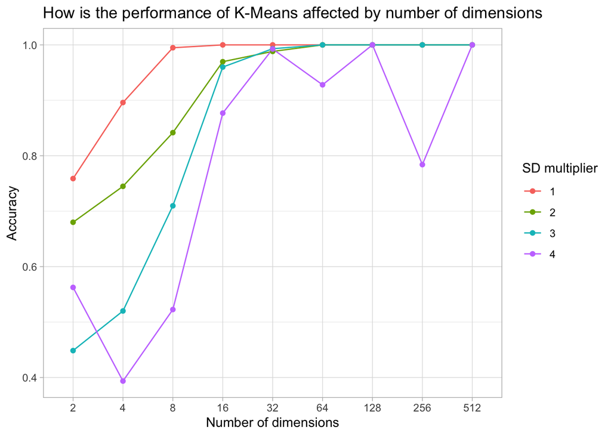

```r
results %>%
  ggplot(aes(x = as.factor(ndim), y = results, colour = as.factor(sd_mult))) +
  geom_line(aes(group = as.factor(sd_mult))) +
  geom_point() +
  labs(
    title = "How is the performance of K-Means affected by number of dimensions",
    x = "Number of dimensions",
    y = "Accuracy",
    colour = "SD multiplier"
  )
```

```r
n_clusters = 8
```

## Analysis with 8 Clusters

Next we try the same analysis, this time with 8 clusters. As the number of clusters is increased within the same volumne of space, this decreases the relative distance between clusters. We therefore expect the clustering performance (accuracy) to decrease.

```r
start_time <- proc.time()
results <- numeric(nrow(params))
verbose <- ifelse(interactive() & n_clusters > 9, TRUE,  FALSE)
for (i in 1:nrow(params)) {
  output <- run_clustering(ndim = params[i, 1], k = n_clusters, sd_mult = params[i, 2], verbose = verbose)
  results[i] <- output$best_acc
}
results <- cbind(params, results)
end_time <- proc.time()
end_time - start_time
```

```
##    user  system elapsed
## 287.361   1.351 289.066
```

## Results with 8 Clusters

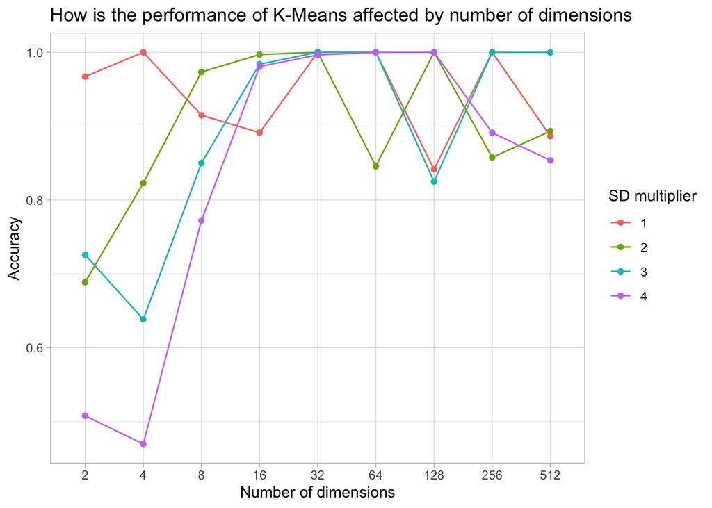

```r
results %>%
  ggplot(aes(x = as.factor(ndim), y = results, colour = as.factor(sd_mult))) +
  geom_line(aes(group = as.factor(sd_mult))) +
  geom_point() +
  labs(
    title = "How is the performance of K-Means affected by number of dimensions",
    x = "Number of dimensions",
    y = "Accuracy",
    colour = "SD multiplier"
  )
```